# Micro - The Model Object

David Smith

3/29/2021

```r
source("MicroMoB.R")
```

# The Model Object

## Design

### Current State

NOTES:

- The template for `pathogen` is `Micro-Pathogen-PfSI.R`

### 0. Overview

The `Model` object (a list) is a defined set of components (also lists) and etcetera (also lists).

**Model Components**

These objects define the model.

- `landscape` – the point sets where events occur
- `host` – variables describing the behavior of the host populations
- `pathogen` – variables for pathogen infection dynamics in their vertebrate hosts
- `mosquito` – variables and parameters for mosquito population and infection dynamics
- `vectorcontrol` – the parameters and models that determine the effects and effect sizes of vector control.
- `intervene` – implements some kinds of interventions, such as reactive case detection or mass interventions.
- `update` – to update the `landscape` or other

**Etcetera**

These objects determine how long the model runs, what output is produced,

- `runtime` – parameters that tell the model how to run
- `io` – a list of objects that produce output
- `state` – the default location to store outputs generated by `io`
- `modify` – a set of routines that can modify the model

### Model Components

#### 1. `landscape`

##### 1.1

A basic component of a microsimulation object is the `landscape` made of of `sites`. There are four main types of sites:

- `haunts`
- `habitats`
- `sugar`
- `facility`

For convenience, the `landscape` also knows how many of each thing is in its list:

- `nHaunts`
- `nHabitats`
- `nSugar`
- `nFacility`

Each thing has features:

- `XY` is the locations, for plotting and setup
- `vars` is a set of variables, in some models
- `pars` is a set of parameters describing the site

##### 1.2 Generic `makeLandscape`

This is the generic function to create a landscape.

```r
makeLandscape = function(mod, par=NULL){
  # Defined in Micro-ModelObject.Rmd
  if(is.null(par)) {
    par = list()
    class(par) <- "demo"
  }
  UseMethod("makeLandscape", par)
}
```

##### 1.3 `makeLandscape.demo`

```r
makeLandscape.demo = function(mod, par){
  # Defined in Micro-ModelObject.Rmd
  landscape = list()

  # Bounding Box
  limits = list(xmin=-10, xmax=10, ymin=-10, ymax=10)
  class(limits) <- "limits"
  landscape$limits = limits

  # Haunts
  nHaunts = 99
  landscape$haunts = list()
  landscape$nHaunts = nHaunts
  landscape$haunts$XY = unifXY(nHaunts, limits)

  # Habitats
  nHab = 121
  landscape$habitats = list()
  landscape$nHabitats = nHab
  landscape$habitats$XY = unifXY(nHab, limits)

  # Sugar
  landscape$nSugar = 0
  landscape$sugar = list()
  landscape$sugar$XY = NULL

  # Facilities
  landscape$nFacility = 0
  landscape$facility = list()
  landscape$facility$XY = NULL

  mod$landscape = landscape
  return(mod)
}
```

##### 1.4 Plotted

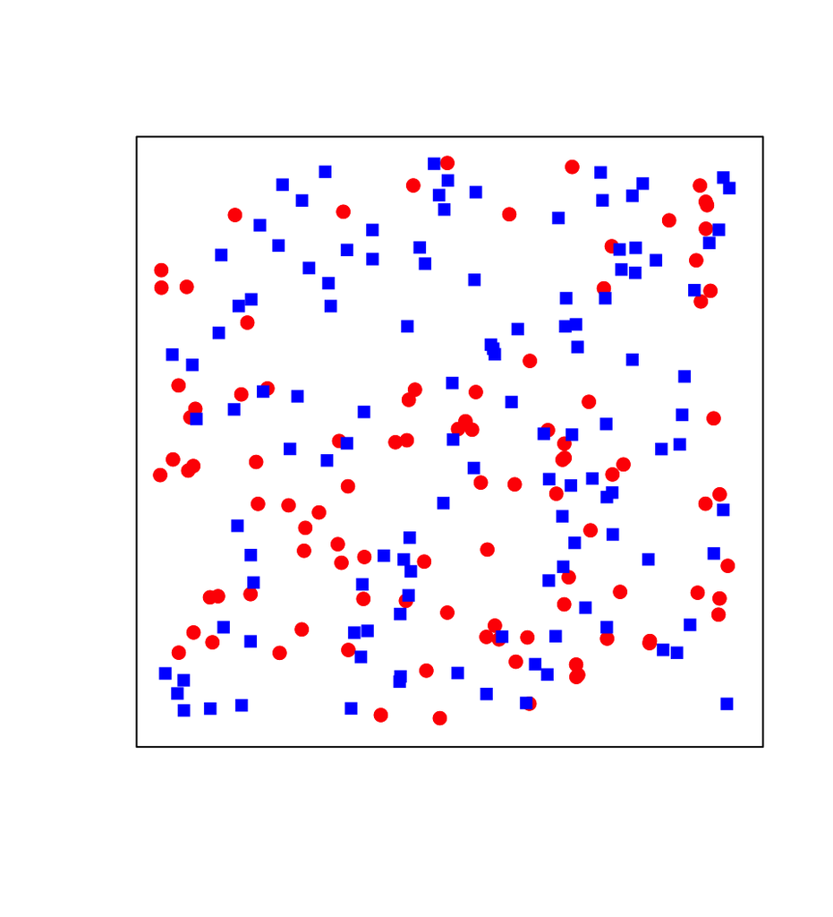

Figure: Locations of haunts (red) and habitats (blue)

```r
Mod = list()
Mod = makeLandscape(Mod)
plotPoints(Mod$landscape)
```

#### 2. `mosquito`

##### 2.1 Structure

- name

*Set Up*

- setupParameters

*Aquatic*

- aquaPars, aquaBase
  - $\rightarrow \mbox{dLdt}()$
  - $\rightarrow \mbox{getEmergents}()$
  - $\star$ emerged
- aquaVars $\\$

*Adults*

- adultPars, adultBase
  - $\rightarrow \mbox{dMdt}(...)$
  - $\rightarrow \mbox{getEggs}()$
  - $\star$ eggs
  - $\rightarrow \mbox{getZ}()$
  - $\star$ Z
- adultVars

*Blood Feeding*

- searchWt (for hosts)
- altWt (for blood hosts)
- tarPars
  - $\rightarrow \mbox{TaRModel}()$
  - $\star$ FeedingRate
  - $\star$ TaR
- choosePars
  - $\rightarrow \mbox{ChooseHost}()$
  - $\star$ Q
- feedingsuccessPars
  - $\rightarrow \mbox{FeedingSuccess}()$
  - $\star$ adultPars$psi.b
- survivefeedingPars
  - $\rightarrow \mbox{SurviveBloodFeeding}()$
  - $\star$ adultPars$p.b
  - $\star$ kappa

##### 2.2 Generic `makeMosquito`

```r
makeMosquito = function(mod, par=NULL){
  # Defined in Micro-ModelObject.Rmd

   if(is.null(par)) {
    par = list()
    class(par) <- "demo"
  }
  UseMethod("makeMosquito", par)
}
```

##### 2.3 `makeMosquito.demo`

```r
makeMosquito.demo = function(mod, par=NULL){
  # Defined in Micro-ModelObject.Rmd

  mod$mosquito = list()
  mod$nMosquito = 1
  mod$mosquito[[1]] = list()
  mod = setup.dLdt(1, "Lambda", mod, Lambda=2)
  #mod = setup.dLdt(1, "BH", mod, K=2)
  mod = setup.dMdt(1, "rm", mod, scl=1000)

  # Blood Feeding
  mod = setup.BloodFeeding("basic", mod)
  mod = setup.AltBloodHosts("null", mod)
  mod = setup.TaR(1,"null", mod)
  mod = setup.SiG(1,"null", mod)
  mod = setup.Bionomics(1,"null", mod)

  return(mod)
}
```

```r
Mod = makeMosquito(Mod)
```

```
## [1] "Setting up dLdt.Lambda"
## [1] "Setting up dMdt.rm"
## [1] "Basic Blood Feeding"
## [1] "null AltBloodHost model"
## [1] "null TaR model"
## [1] "null SiG model"
## [1] "null Bionomics models"
```

#### 3. `host`

##### 3.1 Design

The `host` object:

- popSize
- bitingWeight
- homeID

*Location*

- timespentPars
  - $\rightarrow \mbox{SpendTime}()$
  - $\star$ TimeSpent $(\leftarrow)$
- travelPars
  - $\rightarrow \mbox{Travel}()$
  - $\star$ TravelAR

*Pathogens and Infection*

- nPathogen
- pathogen $<>$

*Disease*

- feverPars
  - $\rightarrow \mbox{Fever}()$
  - $\star$ Fever
  - $\star$ Severe

*Care Seeking*

- careseekPars
  - $\rightarrow \mbox{CareSeeking}()$
  - $\star$ pmfFacilities
  - $\star$ Chemoprotected

*Behavior and Risk*

- *itnOwn*
- *itnUse*

##### 3.2 Generic `makeHuman`, `makeHost`

```r
makeHuman = function(mod, par=NULL){
  # Defined in Micro-ModelObject.Rmd

  if(is.null(par)) {
    par = list()
    class(par) <- "demo"
  }
  UseMethod("makeHuman", par)
}
```

```r
makeHost = function(mod, par=NULL){
  # Defined in Micro-ModelObject.Rmd

  if(is.null(par)) {
    par = list()
    class(par) <- "demo"
  }
  UseMethod("makeHost", par)
}
```

##### `makeHuman.demo`

```r
makeHuman.demo = function(mod, par=NULL){
  # Defined in Micro-ModelObject.Rmd
  mod = setup.human("demo", mod, 100)
  mod = setup.timespent.null("null", mod, scl=1000)
  mod = setup.fever("null", mod)
  mod = setup.careseeking("null", mod)
  mod = setup.travel("null", mod, TravelAR = 0.001)
  return(mod)
}
```

```r
Mod = makeHuman(Mod)
```

```
## [1] "Setting up human"
## [1] "Setting up timespent"
## [1] "Setting up fever"
## [1] "Setting up CareSeeking"
## [1] "Setting up Travel"
```

##### `makeHost.demo`

```r
makeHost.demo = function(mod, par=NULL){
  # Defined in Micro-ModelObject.Rmd

  mod = setup.human("demo", mod, 100)
  mod = setup.timespent.null("null", mod, scl=1000)
  mod = setup.travel("null", mod, TravelAR = 0.001)
  return(mod)
}
```

```r
Mod1 = makeHost(Mod)
```

```
## [1] "Setting up human"
## [1] "Setting up timespent"
## [1] "Setting up Travel"
```

#### 4. `pathogen`

##### 4.1 Design

The model is capable of simulating multiple pathogens.

- pathogenName
- vars
- pars

Each pathogen can also set up it’s own `io`

##### 4.2 Generic `makePathogen`

```r
makePathogen = function(mod, par=NULL){
  # Defined in Micro-ModelObject.Rmd
  if(is.null(par)) {
    par = list()
    class(par) <- "demo"
  }
  if(is.null(par)) class(par) <- "demo"
  UseMethod("makePathogen", par)
}
```

##### 4.3 `makePathogen.demo`

```r
Mod = setup.pathogen(1, "pfsi", Mod)
```

#### 5. `vectorcontrol`

#### 6. `intervene`

#### 7. `update`

### Etcetera

Each model needs a set of functions to run it, produce and store output.

#### `io`

`IO` is a list of functions. By default, outputs are stored in `Model$state`.

#### `update`

An update is a generic function in a list that can change parameters or other features of a model.

- `update$F` is a function of the form `F(t, Mod, pars)`
- `update$pars` holds the parameters passed to the function `F`

The `update` object is an arbitrarily long list of updates.

```r
Update = function(t, Mod){
  # Defined in Micro-ModelObject.Rmd
  if(length(Mod$update)>0){
    for(i in 1:length(Mod$update)){
      Mod = update(i,t,Mod)
    }
  }
  return(Mod)
}
```

```r
addUpdate = function(mod, protocol, pars){
  # Defined in Micro-ModelObject.Rmd

  i = length(mod$updateLandscape)+1
  mod$update[[i]] = list()
  mod$update[[i]]$F = protocol
  mod$update[[i]]$pars = pars
  mod
}
```

## Demo

```r
makeModel.demo = function(){
  # Defined in Micro-ModelObject.Rmd
   model = list()

   # runtime
   runtime       = list()
   runtime$T0    = 0
   runtime$Tmax  = 10
   model$runtime = runtime

   # modifiable
   model$io        = list()
   model$state     = list()
   model$intervene = list()
   model$update    = list()

   # objects
   model    = makeLandscape(model)
   model    = makeMosquito(model)
   model    = makeHuman(model)
   model    = setup.pathogen(1, "pfsi", model)

   return(model)
}
```

```r
model = makeModel.demo()
```

```
## [1] "Setting up dLdt.Lambda"
## [1] "Setting up dMdt.rm"
## [1] "Basic Blood Feeding"
## [1] "null AltBloodHost model"
## [1] "null TaR model"
## [1] "null SiG model"
## [1] "null Bionomics models"
## [1] "Setting up human"
## [1] "Setting up timespent"
## [1] "Setting up fever"
## [1] "Setting up CareSeeking"
## [1] "Setting up Travel"
```